# Distribuciones de probabilidad

Maestría en Ciencia de Datos

2023-11-24

## Distribuciones de probabilidad

Una **distribución de probabilidad** es un concepto fundamental en estadística que describe cómo se distribuyen los valores de una variable aleatoria. Dependiendo de si la variable es discreta (toma valores específicos) o continua (puede tomar cualquier valor en un rango), las distribuciones se clasifican en distribuciones de probabilidad discretas o continuas.

### Distribución de Probabilidad

1. **Para Variables Discretas**:
   - Se describe generalmente mediante una **función de masa de probabilidad (PMF)**, que asigna una probabilidad a cada posible valor de la variable.
   - Ejemplo: En la distribución binomial, la PMF te diría la probabilidad de obtener un cierto número de caras en un número de lanzamientos de una moneda.
2. **Para Variables Continuas**:
   - Se utiliza una **función de densidad de probabilidad (PDF)**, que describe la probabilidad relativa de que la variable aleatoria tome un valor en un intervalo específico.
   - La probabilidad de que una variable continua tome un valor exacto es 0; en su lugar, se habla de la probabilidad de que caiga dentro de un rango.
   - Ejemplo: La distribución normal se describe con una PDF que muestra una curva de campana.

### Función de Distribución Acumulada

La **función de distribución acumulada (CDF)** es otra herramienta clave. Proporciona la probabilidad de que la variable aleatoria tome un valor igual o menor que un valor específico.

1. **Para Variables Discretas**:
   - La CDF es una función escalonada que aumenta en cada valor donde la PMF tiene una probabilidad positiva.
2. **Para Variables Continuas**:
   - La CDF es una función continua que aumenta desde 0 a 1.
   - Es la integral de la PDF.

### Interpretación y Uso

- **Interpretación**: Las distribuciones de probabilidad son esenciales para comprender la naturaleza de los datos y para realizar inferencias estadísticas. Por ejemplo, determinar si un conjunto de datos sigue una distribución normal puede influir en el tipo de pruebas estadísticas que se aplican.
- **Uso en Modelado**: Las distribuciones se usan para modelar fenómenos en varios campos, como la física, la biología, la economía y las ciencias sociales.
- **En Análisis Predictivo**: Las distribuciones ayudan a predecir la probabilidad de diferentes resultados y a tomar decisiones basadas en la probabilidad de varios escenarios.

En resumen, las distribuciones de probabilidad proporcionan un marco para entender y predecir el comportamiento de las variables aleatorias, lo que es fundamental en estadística y análisis de datos.

### PMF binomial

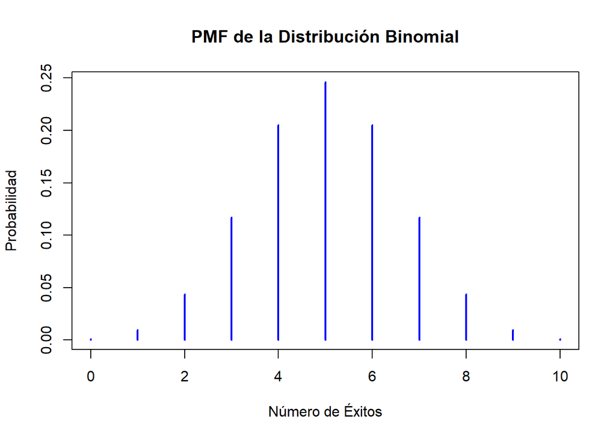

```r
# Parámetros para la distribución binomial
n_binomial <- 10
p_binomial <- 0.5

# Crear valores para x y calcular PMF
x_binomial <- 0:n_binomial
pmf_binomial <- dbinom(x_binomial, size = n_binomial, prob = p_binomial)

# Gráfico de la PMF
plot(x_binomial, pmf_binomial, type = "h", lwd = 2, col = "blue",
     main = "PMF de la Distribución Binomial",
     xlab = "Número de Éxitos",
     ylab = "Probabilidad")
```

### CDF binomial

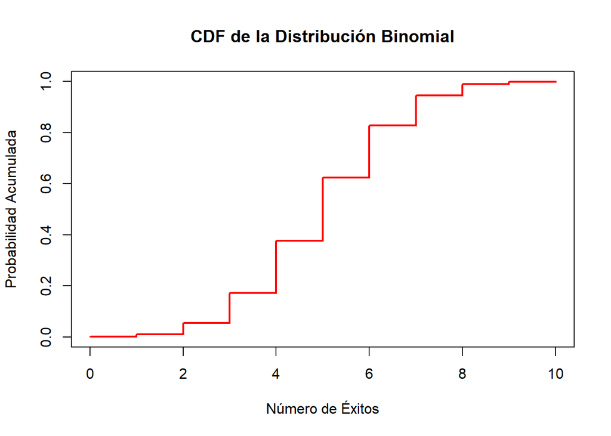

```r
# Calcular CDF
cdf_binomial <- pbinom(x_binomial, size = n_binomial, prob = p_binomial)

# Gráfico de la CDF
plot(x_binomial, cdf_binomial, type = "s", lwd = 2, col = "red",
     main = "CDF de la Distribución Binomial",
     xlab = "Número de Éxitos",
     ylab = "Probabilidad Acumulada")
```

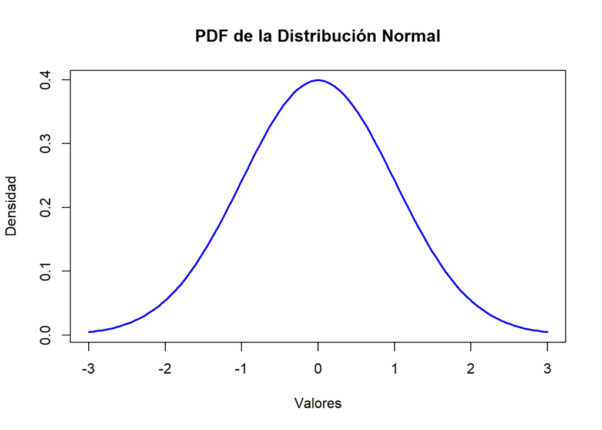

```r
# Parámetros para la distribución normal
mu_normal <- 0
sigma_normal <- 1

# Crear valores para x y calcular PDF
x_normal <- seq(-3, 3, length.out = 100)
pdf_normal <- dnorm(x_normal, mean = mu_normal, sd = sigma_normal)

# Gráfico de la PDF
plot(x_normal, pdf_normal, type = "l", lwd = 2, col = "blue",
     main = "PDF de la Distribución Normal",
     xlab = "Valores",
     ylab = "Densidad")
```

### CDF Normal

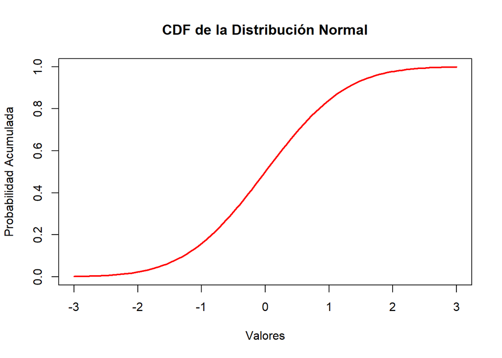

```r
# Calcular CDF
cdf_normal <- pnorm(x_normal, mean = mu_normal, sd = sigma_normal)

# Gráfico de la CDF
plot(x_normal, cdf_normal, type = "l", lwd = 2, col = "red",
     main = "CDF de la Distribución Normal",
     xlab = "Valores",
     ylab = "Probabilidad Acumulada")
```

## Distribuciones discretas más comunes

### Distribución binomial

Interpretación: Usada para modelar el número de éxitos en una cantidad fija de ensayos independientes, donde cada ensayo tiene solo dos resultados (éxito o fracaso) y la probabilidad de éxito es constante.

$$P(X=k)=\left(\begin{array}{l}
n \\
k
\end{array}\right) p^k(1-p)^{n-k}$$

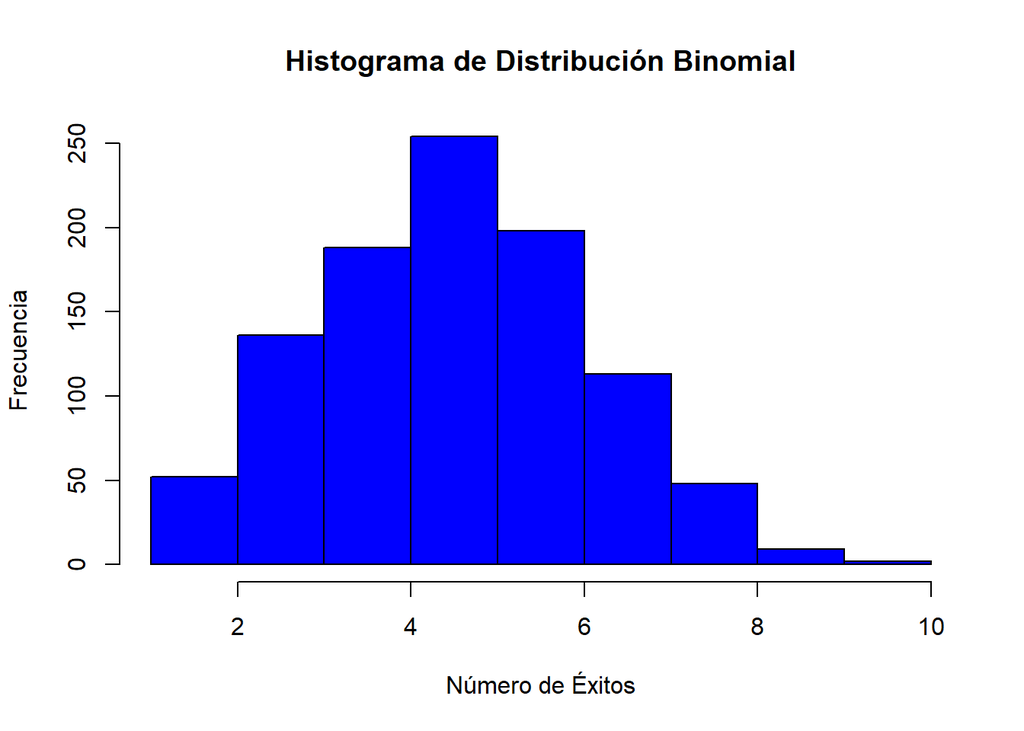

```r
# Generar datos binomiales
n_binomial <- 10
p_binomial <- 0.5
datos_binomial <- rbinom(1000, n_binomial, p_binomial)

# Crear un histograma
hist(datos_binomial, main = "Histograma de Distribución Binomial", xlab = "Número de Éxitos", ylab = "Frecuencia", col = "blue", breaks = n_binomial+1)
```

### Distribución de Poisson

Interpretación: Adecuada para modelar el número de veces que ocurre un evento en un intervalo de tiempo o espacio, asumiendo que estos eventos ocurren con una tasa constante y de manera independiente.

$$P(X=k)=\frac{e^{-\lambda} \lambda^k}{k !}$$

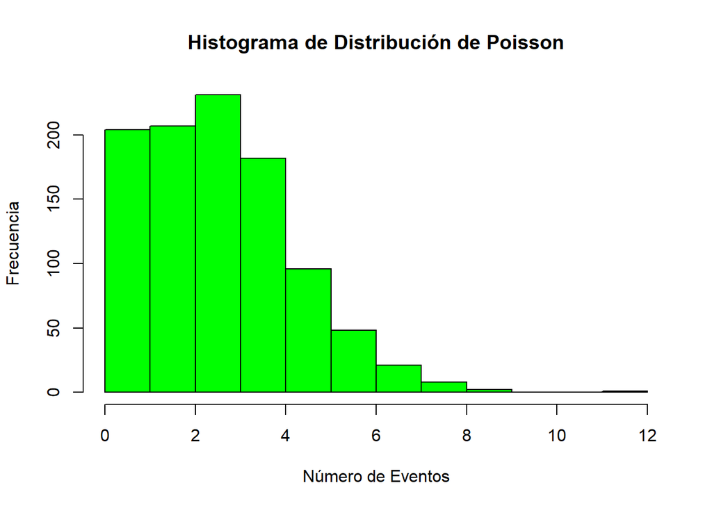

```r
# Generar datos de Poisson
lambda_poisson <- 3
datos_poisson <- rpois(1000, lambda_poisson)

# Crear un histograma
hist(datos_poisson, main = "Histograma de Distribución de Poisson", xlab = "Número de Eventos", ylab = "Frecuencia", col = "green", breaks = max(datos_poisson)+1)
```

### Distribución geométrica

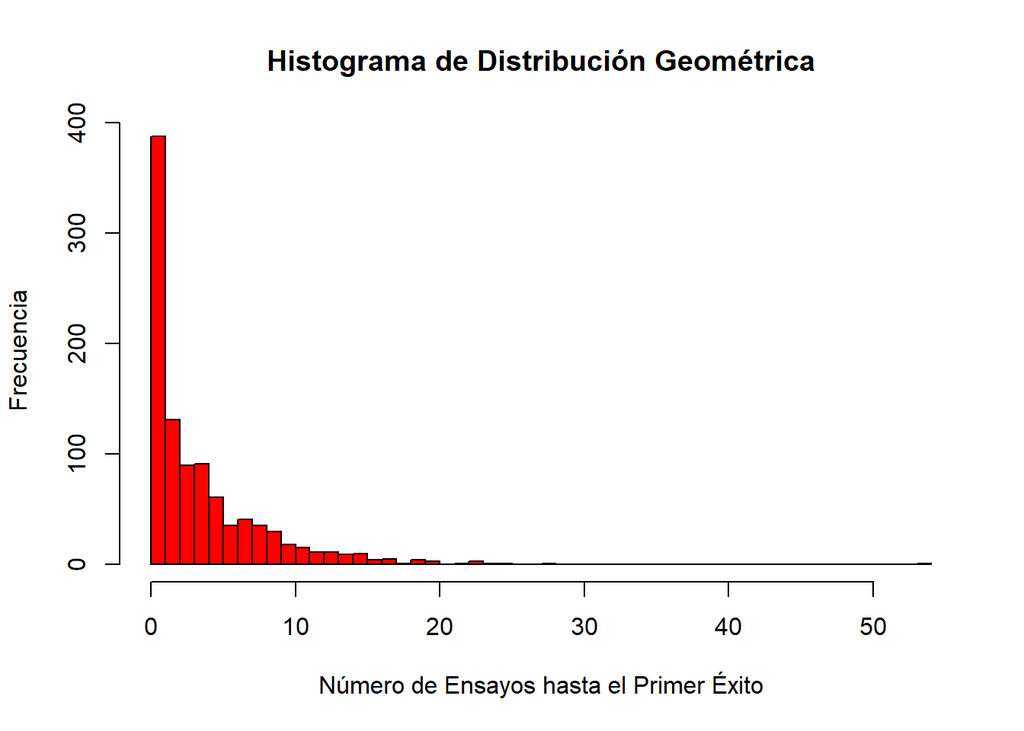

```r
# Generar datos geométricos
p_geometric <- 0.2
datos_geometric <- rgeom(1000, p_geometric)

# Crear un histograma
hist(datos_geometric, main = "Histograma de Distribución Geométrica", xlab = "Número de Ensayos hasta el Primer Éxito", ylab = "Frecuencia", col = "red", breaks = max(datos_geometric)+1)
```

### Distribución Uniforme Discreta

En R, podemos simular una distribución uniforme discreta, por ejemplo, el lanzamiento de un dado:

$$P(X=x)=\frac{1}{n}$$

Donde $n$ es el número de resultados posibles y $x$ es un resultado específico. Todos los resultados son igualmente probables.

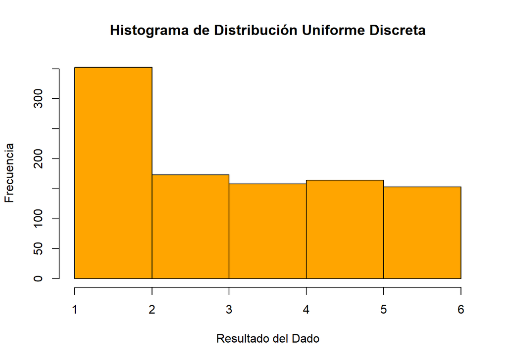

```r
# Lanzamiento de un dado (6 caras)
dados <- sample(1:6, 1000, replace = TRUE)

# Histograma
hist(dados, main = "Histograma de Distribución Uniforme Discreta", xlab = "Resultado del Dado", ylab = "Frecuencia", col = "orange", breaks = 6)
```

### Distribución Hipergeométrica

Vamos a simular una situación donde sacamos 10 bolas de una urna que contiene 20 bolas rojas y 30 azules, y contamos cuántas rojas obtenemos:

$$P(X=k)=\frac{\left(\begin{array}{l}
K \\
k
\end{array}\right)\left(\begin{array}{c}
N-K \\
n-k
\end{array}\right)}{\left(\begin{array}{l}
N \\
n
\end{array}\right)}$$

Donde $N$ es el tamaño de la población, $K$ es el número de éxitos en la población, $n$ es el tamaño de la muestra, y $k$ es el número de éxitos observados en la muestra.

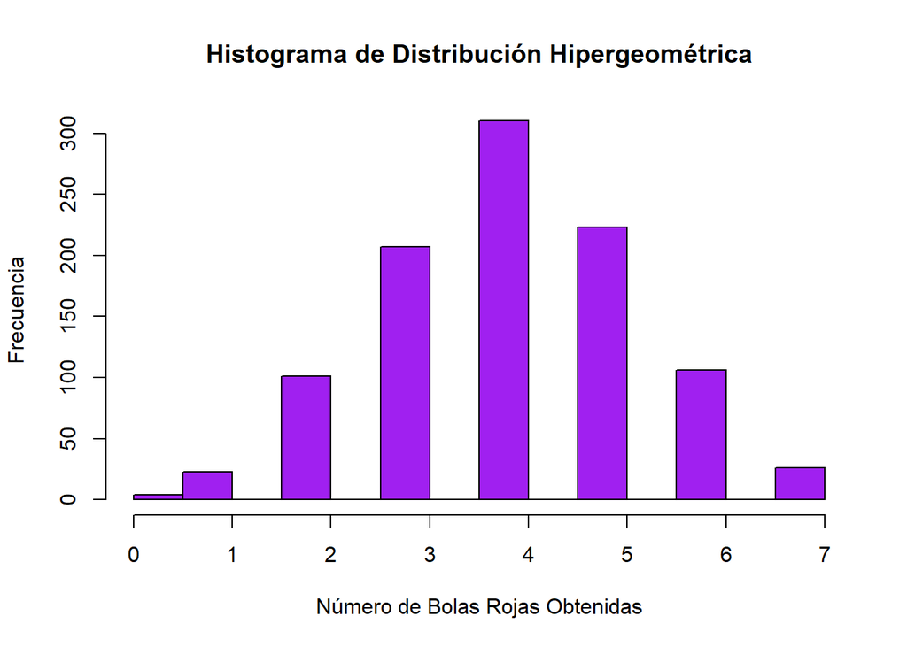

```r
# Parámetros: 20 bolas rojas, 30 azules, sacamos 10
hipergeometrica <- rhyper(1000, 20, 30, 10)

# Histograma
hist(hipergeometrica, main = "Histograma de Distribución Hipergeométrica", xlab = "Número de Bolas Rojas Obtenidas", ylab = "Frecuencia", col = "purple")
```

### Distribución Binomial Negativa

$$P(X=k)=\left(\begin{array}{c}
k-1 \\
r-1
\end{array}\right) p^r(1-p)^{k-r}$$

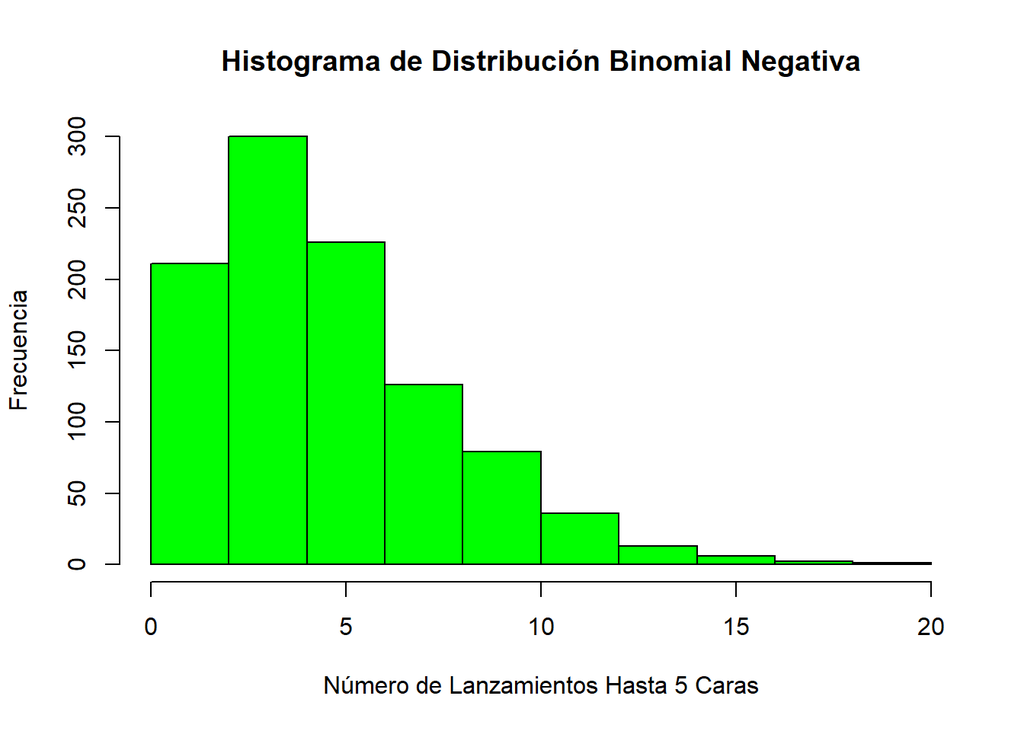

```r
# Parámetros: 5 éxitos, probabilidad de cara 0.5
binomial_negativa <- rnbinom(1000, size = 5, prob = 0.5)

# Histograma
hist(binomial_negativa, main = "Histograma de Distribución Binomial Negativa", xlab = "Número de Lanzamientos Hasta 5 Caras", ylab = "Frecuencia", col = "green")
```

### Distribución de Bernoulli

Simularemos el resultado de 1000 lanzamientos de una moneda:

La fórmula para la distribución de Bernoulli es la siguiente:

$$P(X = k) =
\begin{cases}
p & \text{si } k=1 \\
1-p & \text{si } k=0
\end{cases}$$

Donde $p$ es la probabilidad de éxito y $1-p$ es la probabilidad de fracaso.

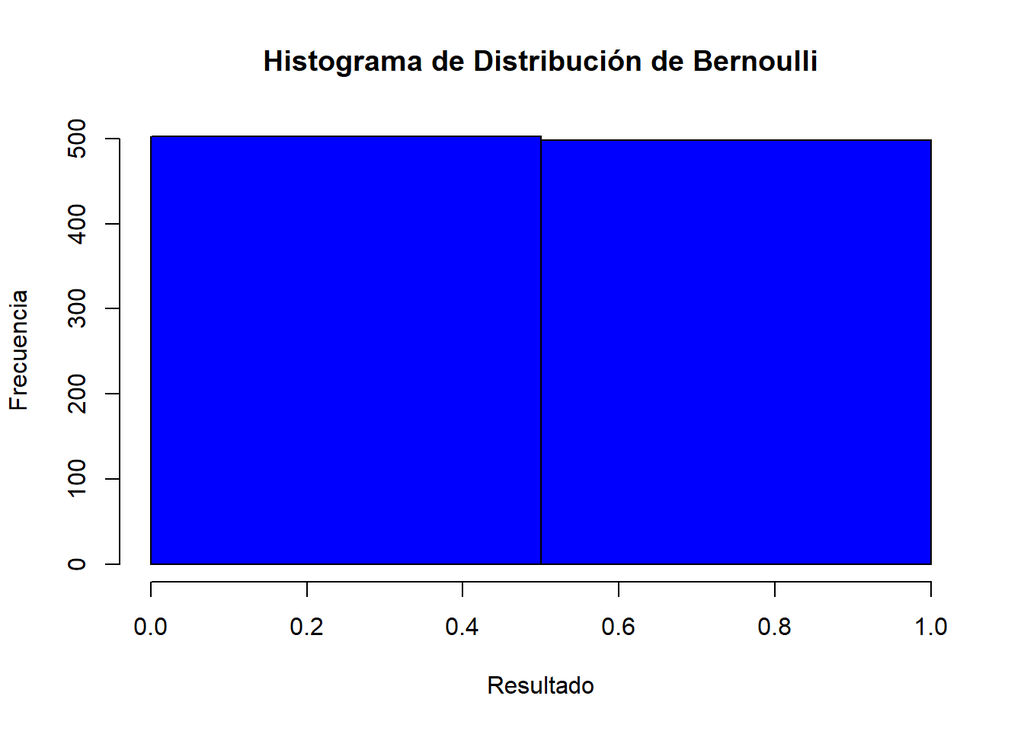

```r
# Lanzamiento de moneda (0 = cruz, 1 = cara)
bernoulli <- rbinom(1000, size = 1, prob = 0.5)

# Histograma
hist(bernoulli, main = "Histograma de Distribución de Bernoulli", xlab = "Resultado", ylab = "Frecuencia", col = "blue", breaks = 2)
```

## Distribuciones continuas más comunes

### Distribución normal

Interpretación: Describe una variable continua donde las observaciones tienden a agruparse alrededor de un valor medio. Se utiliza en una variedad de campos debido a su relación con el Teorema Central del Límite.

$$f(x)=\frac{1}{\sqrt{2 \pi \sigma^2}} e^{-\frac{(x-\mu)^2}{2 \sigma^2}}$$

Donde $\mu$ es la media y $\sigma$ es la desviación estándar.

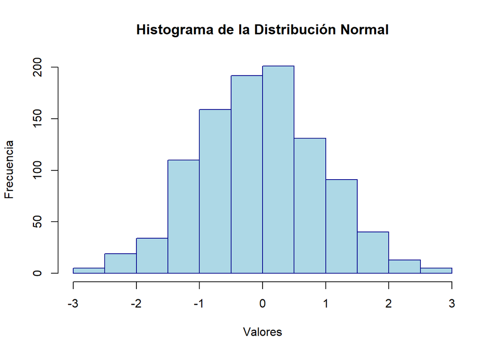

```r
# Generar datos de una distribución normal
datos_normales <- rnorm(1000, mean = 0, sd = 1)

# Histograma
hist(datos_normales, main = "Histograma de la Distribución Normal", xlab = "Valores", ylab = "Frecuencia", col = "lightblue", border = "darkblue")
```

### Distribución Exponencial

Interpretación: Usada para modelar el tiempo entre eventos en un proceso de Poisson, como el tiempo hasta el próximo fallo de una máquina.

$$f(x)=\lambda e^{-\lambda x}$$

Donde $\lambda$ es la tasa de ocurrencia.

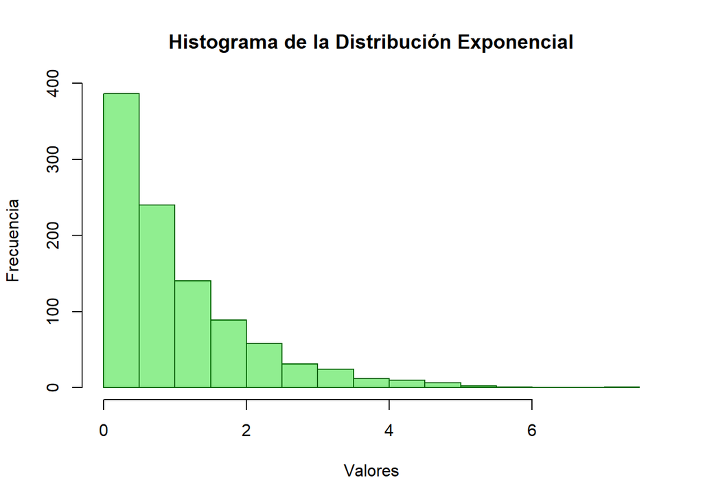

```r
# Generar datos de una distribución exponencial
datos_exponenciales <- rexp(1000, rate = 1)

# Histograma con mejor formato
hist(datos_exponenciales, main = "Histograma de la Distribución Exponencial", xlab = "Valores", ylab = "Frecuencia", col = "lightgreen", border = "darkgreen")
```

### Distribución de Weibull

Interpretación: Una distribución versátil usada en análisis de fiabilidad y estudios de vida útil. Permite modelar diversas formas de tasas de fallo.

$$f(x)=\frac{\beta}{\alpha}\left(\frac{x}{\alpha}\right)^{\beta-1} e^{-(x
/ \alpha)^\beta}$$

Donde $\alpha$ es el parámetro de escala y $\beta$ es el parámetro de forma.

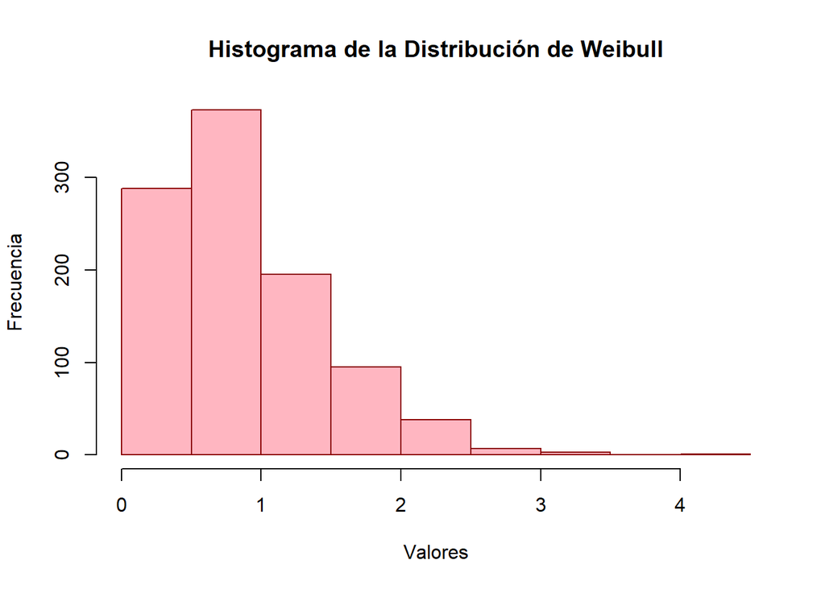

```r
# Generar datos de una distribución de Weibull
datos_weibull <- rweibull(1000, shape = 1.5, scale = 1)

# Histograma
hist(datos_weibull, main = "Histograma de la Distribución de Weibull", xlab = "Valores", ylab = "Frecuencia", col = "lightpink", border = "darkred")
```

#### Distribución Log-Normal

Interpretación: Usada para modelar variables que representan el logaritmo de una variable normalmente distribuida. Común en análisis financiero y estudios ambientales.

$$f(x)=\frac{1}{x \sigma \sqrt{2 \pi}} e^{-\frac{(\ln x-\mu)^2}{2
\sigma^2}}$$

Donde $\mu$ y $\sigma$ son los parámetros de la distribución log-normal.

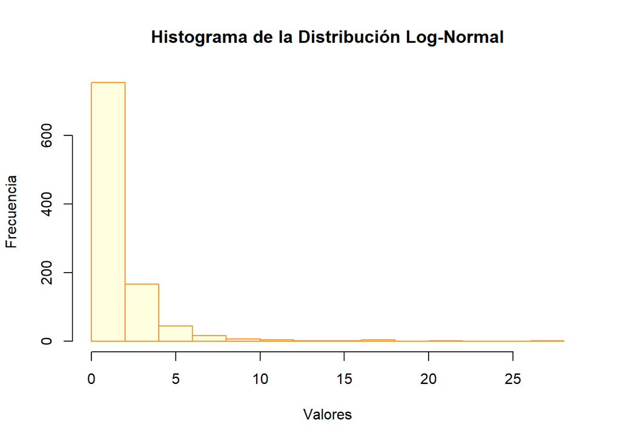

```r
# Generar datos de una distribución log-normal
datos_lognormales <- rlnorm(1000, meanlog = 0, sdlog = 1)

# Histograma
hist(datos_lognormales, main = "Histograma de la Distribución Log-Normal", xlab = "Valores", ylab = "Frecuencia", col = "lightyellow", border = "darkorange")
```